# Demand and Supply

Economics

Paulo Fagandini

Universidade Europeia

# Demand, Supply, and Equilibrium in Markets for Goods and Services

## Demand, Supply, and Equilibrium in Markets for Goods and Services

- **Demand** - the amount of some good or service consumers are willing and able to purchase at each price.
- **Price** - what a buyer pays for a unit of the specific good or service.
- **Quantity demanded** - the total number of units of a good or service consumers are willing to purchase at a given price
- **Law of demand** - keeping all other variables that affect demand constant,
  - if price $\uparrow$ , then quantity demanded $\downarrow$
  - If price goes $\downarrow$ , then quantity demanded $\uparrow$

## Demand Schedule & Curve

- **Demand schedule** - a table that shows a range of prices for a certain good or service and the quantity demanded at each price.
- **Demand curve** - a graphic representation of the relationship between price and quantity demanded of a certain good or service, with quantity on the horizontal axis and the price on the vertical axis.

## Demand Schedule

| Price | Quantity |
| --- | --- |
| 2.20 | 420 |
| 2.00 | 460 |
| 1.80 | 500 |
| 1.60 | 550 |
| 1.40 | 600 |
| 1.20 | 700 |
| 1.00 | 800 |

## Graphing the Demand

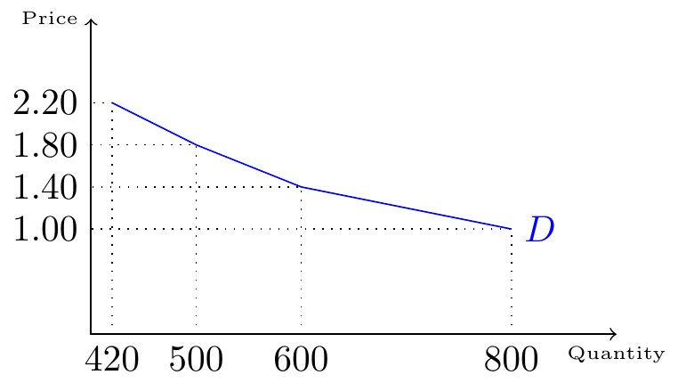

## Graphing the Demand

- The points of a demand schedule are graphed, and the line connecting them is the **demand curve** (D).
- The downward slope of the demand curve again illustrates the *law of demand* - the inverse relationship between prices and quantity demanded.

## Supply of Goods and Services

- **Supply** - the amount of some good or service a producer is willing to supply at each price.
- **Quantity supplied** - the total number of units of a good or service producers are willing to sell at a given price.
- **Law of supply** - assuming all other variables that affect supply are held constant,
  - if price goes $\uparrow$ , then quantity supplied goes $\uparrow$
  - if price goes $\downarrow$, then quantity supplied goes $\downarrow$

## Supply Schedule & Curve

- **Supply schedule** - a table that shows the quantity supplied at a range of different prices.
- **Supply curve** - a graphic illustration of the relationship between price, shown on the vertical axis, and quantity, shown on the horizontal axis.

## Supply Schedule

| Price | Quantity |
| --- | --- |
| 2.20 | 720 |
| 2.00 | 700 |
| 1.80 | 680 |
| 1.60 | 640 |
| 1.40 | 600 |
| 1.20 | 550 |
| 1.00 | 500 |

## Graphing the supply

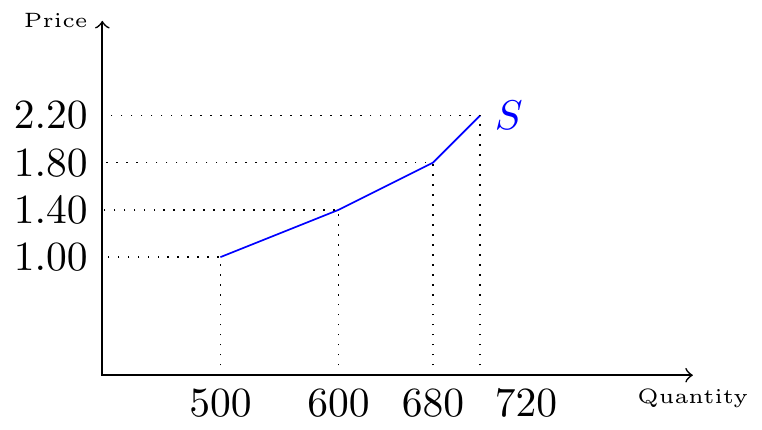

## Graphing the supply

- The **supply curve** (S) is created by graphing the points from a supply schedule and then connecting them.
- The upward slope of the supply curve illustrates the *law of supply* - that a higher price leads to a higher quantity supplied, and vice versa.

## Equilibrium

**Equilibrium**

The combination of price and quantity where there is no economic pressure from surpluses or shortages that would cause price or quantity to change
$$\text{quantity demanded} = \text{quantity supplied}$$

## Equilibrium

- **Equilibrium price** - the price where quantity demanded is equal to quantity supplied
- **Equilibrium quantity** - the quantity at which quantity demanded and quantity supplied are equal for a certain price level.
- **Surplus or excess supply** - at the existing price, quantity supplied exceeds the quantity demanded.
- **Shortage or excess demand** - at the existing price, the quantity demanded exceeds the quantity supplied.

## Equilibrium

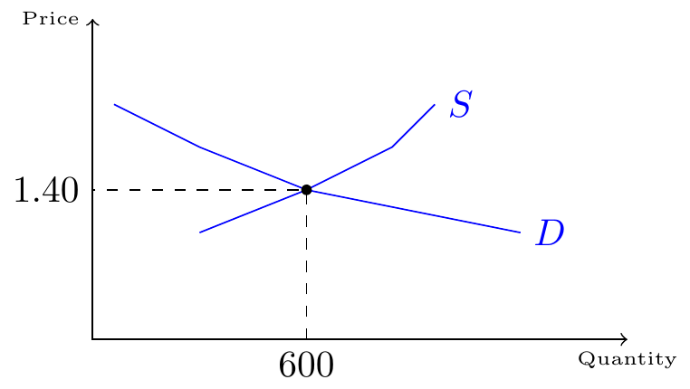

## Equilibrium

- The demand curve ($D$) and the supply curve ($S$) intersect at the equilibrium point $(600, 1.40)$.
- The equilibrium price is the only price where,
  $$\text{quantity demanded } (Q_D) = \text{quantity supplied } (Q_S)$$
- At $p>1.40$, $Q_S>Q_D$ $\Rightarrow$ **excess supply**.
- At $p<1.40$, $Q_D>Q_S$ $\Rightarrow$ **excess demand**.

# Shifts in Demand and Supply for Goods and Services

## Shifts in Demand and Supply for Goods and Services

- **Ceteris paribus** - Latin phrase meaning *other things being equal*
- Any given demand or supply curve is based on the *ceteris paribus* assumption that all else is held equal.

## Demand Curve

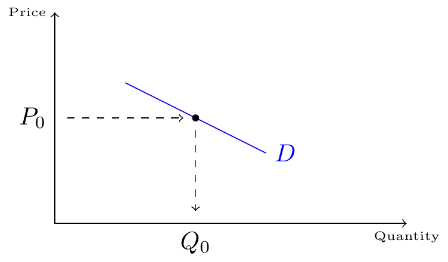

The demand curve can be used to identify how much consumers would buy at any given price.

## If Income increases

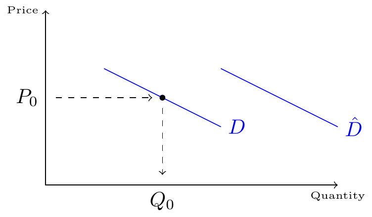

## If Income increases

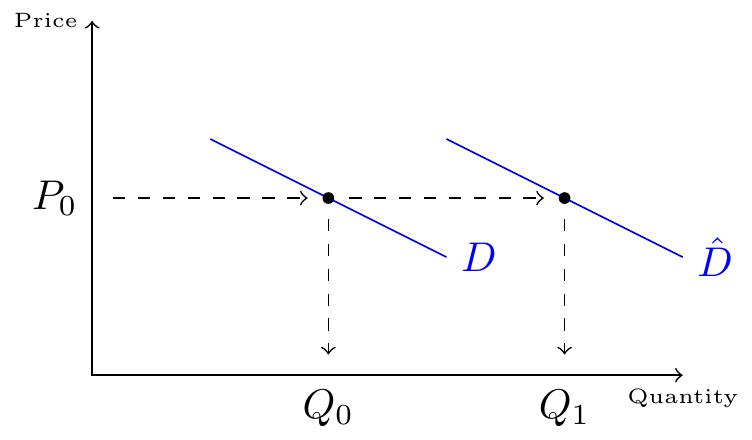

If income increases:

## Shifts because of Income

- Increased demand means that at every given price, the quantity demanded is higher, so that the demand curve shifts to the right from $D$ to $\hat{D}$.
- Decreased demand means that at every given price, the quantity demanded is lower, so that the demand curve shifts to the left from $\hat{D}$ to $D$.

## What Factors Affect Demand?

1. A shift in demand happens when a change in some economic factor (other than price) causes a different quantity to be demanded at every price.
2. Factors that affect demand:
   1. Income
   2. Changing tastes or preferences
   3. Changes in the composition of the population
   4. Price of substitute or complement changes
   5. Changes in expectations about future

## Types of Goods & Services

- **Normal good** - A product whose demand rises when income rises, and vice versa.
- **Inferior good** - A product whose demand falls when income rises, rises, and vice versa.
- **Substitute** - a good or service that we can use in place of another good or service.
- **Complements** - goods or services that are often used together so that consumption of one good tends to enhance consumption of the other.

## Supply Curve

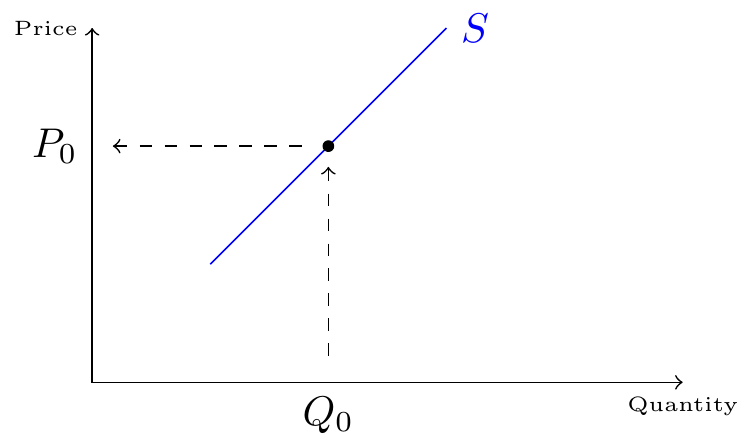

- The supply curve can be used to show the minimum price a firm will accept to produce a given quantity of output.
- $P_0$ equals cost of production plus any margin.

## Supply Curve

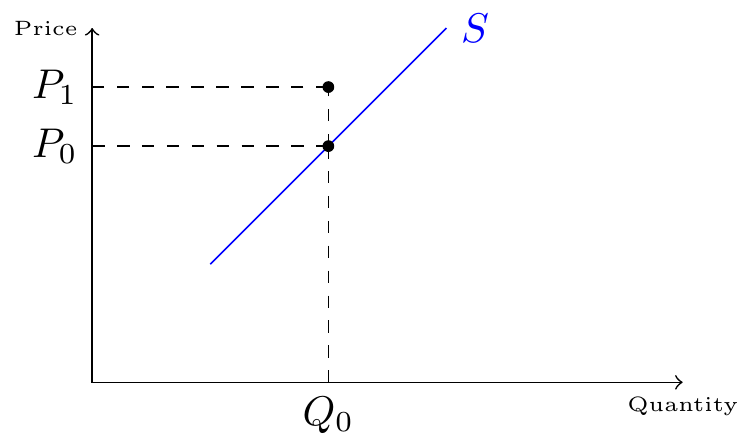

If costs increase…

## Supply Curve

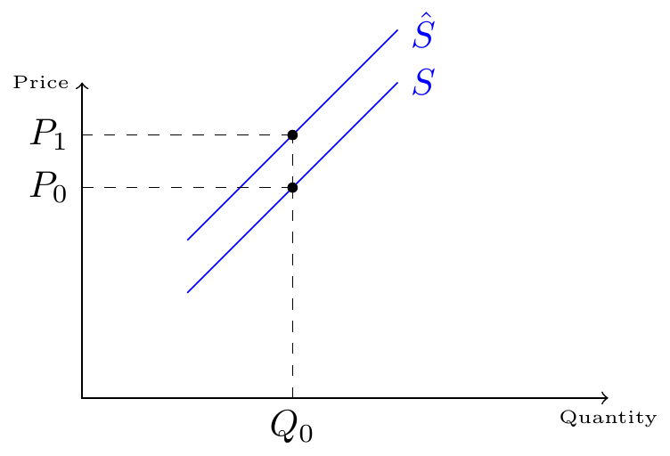

- Then the price, for the same quantity, must also increase!
- When the cost of production increases, the supply curve shifts up to a new price level.

## Shifting the Supply Curve

- Decreased supply means that at every given price, the quantity supplied is lower, so that the supply curve shifts to the *left*, from $S$ to $\hat{S}$.
- Increased supply means that at every given price, the quantity supplied is higher, so that the supply curve shifts to the *right*, from $\hat{S}$ to $S$.

## What Factors Affect Supply?

- **Shift in supply** - when a change in some economic factor (other than price) causes a different quantity to be supplied at every price.
- **Inputs or factors of production** - the combination of labor, materials, and machinery that is used to produce goods and services.
- Factors that affect *supply*:
  - Natural conditions
  - Input prices
  - Technology
  - Government policies

# Changes in Equilibrium Price and Quantity: The Four-Step Process

## Changes in Equilibrium Price and Quantity: The Four-Step Process

Four-step process to determining how an economic event affects equilibrium price and quantity:

1. Draw a demand and supply model before the economic change took place.
2. Decide whether the economic change affects demand or supply.
3. Decide whether the effect causes a curve shift to the right or to the left, and sketch the new curve on the diagram.
4. Identify the new equilibrium and then compare to the original.

## Example: Shift in Supply

1. How did excellent weather conditions during the summer affect the quantity and price of salmon?
2. From 2004 to 2012, the share of Americans who reported obtaining their news from digital sources increased from 24% to 39%. How has this affected the consumption of traditional sources, such as print news media, and radio and television news?
3. What does an increase in labor compensation, as well as an increase in digital communication suggest about the continued viability of the Postal Service?

# Price Ceilings and Price Floors

## Price Ceilings and Price Floors

- **Price controls** - laws that governments enact to regulate prices.
- Price ceiling
  - keeps a price from rising above a certain level
  - a legal maximum price that one pays for some good or service
- Price floor
  - keeps a price from falling below a given level
  - is the lowest price that one can legally pay for some good or service.

## Price Ceilings and Price Floors

1. A Price Ceiling Example - Rent Control
2. A Price Floor Example - European Wheat Prices

# Demand, Supply, and Efficiency

## Demand, Supply, and Efficiency

- Consumer surplus
  - the amount that individuals would have been willing to pay minus the amount that they actually paid.
  - the area above the market price and below the demand curve.

## Demand, Supply, and Efficiency

- Producer surplus
  - the price the producer actually received minus the price the producer would have been willing to accept.
  - the area between the market price and the segment of the supply curve below the equilibrium.

## Demand, Supply, and Efficiency

- Social/economic/total **surplus**
  - consumer surplus + producer surplus
- **Deadweight loss** - the loss in social surplus that occurs when a market produces an inefficient quantity

## Demand, Supply, and Efficiency

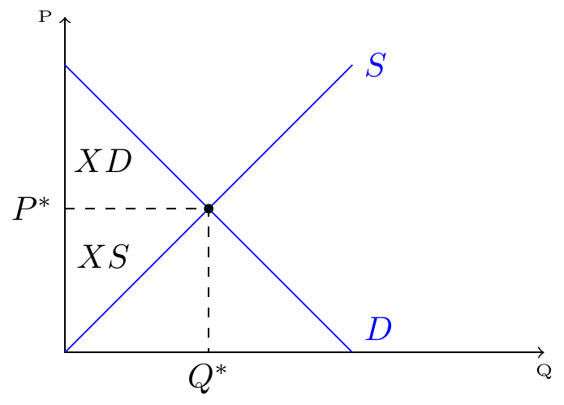

- $XD$: Consumer Surplus, $XS$: Producer Surplus, $XD+XS$: Total Surplus.

## Reference

Shapiro, D.; MacDonald, D.; Greenlaw, S. A. (2022). Principles of Economics 3<sup>e</sup>. OpenStax.

Chapter 3